# Women's Clothing Ecommerce Review: Sentiment Analysis

This project will implement a bidirectional LSTM model to evaluate the sentiment of the reviews and predict two dependent variables:

1. Rating in scale of 1 to 5. 1 is worst and 5 is best. 1 and 2 were considered negative while 4 and 5 are considered positive
2. Recommendation [0 for not recommended and 1 for recommended]

```python
#loading all necessary packages

import numpy as np
import pandas as pd
import matplotlib.pyplot as plt
%matplotlib inline
import seaborn as sns

from IPython.display import display

import warnings
warnings.filterwarnings('ignore')


from pylab import *
from wordcloud import WordCloud, STOPWORDS
import collections


from keras.models import Sequential
from keras.layers import Dense, Input, Dropout, LSTM, Activation, Embedding, Bidirectional
from keras.preprocessing.text import Tokenizer
from keras.initializers import Constant
from keras.callbacks import EarlyStopping, ModelCheckpoint
from keras.utils import to_categorical

from sklearn.model_selection import train_test_split
from sklearn.metrics import roc_curve, auc
from sklearn.metrics import confusion_matrix
import sklearn.metrics as mt
```

```python
#Loading and cleaning the data
review=pd.read_csv('Womens Clothing E-Commerce Reviews.csv')
print ('Raw data input:')
display(review.head())
#print (review.head().to_html())

review=review[['Title','Review Text','Rating','Recommended IND']]

#converting Rating and Recommendation to categorical variables

review['Rating'] = review['Rating'].astype('category')
review['Recommended IND'] = review['Recommended IND'].astype('category')
print ('Checking dataframe data type:',review.dtypes)

print ("Saving subset of the dataset by dropping few features:")
display(review.head())
```

```
Raw data input:
```

|  | Unnamed: 0 | Clothing ID | Age | Title | Review Text | Rating | Recommended IND | Positive Feedback Count | Division Name | Department Name | Class Name |
| --- | --- | --- | --- | --- | --- | --- | --- | --- | --- | --- | --- |
| 0 | 0 | 767 | 33 | NaN | Absolutely wonderful - silky and sexy and comf... | 4 | 1 | 0 | Initmates | Intimate | Intimates |
| 1 | 1 | 1080 | 34 | NaN | Love this dress! it's sooo pretty. i happene... | 5 | 1 | 4 | General | Dresses | Dresses |
| 2 | 2 | 1077 | 60 | Some major design flaws | I had such high hopes for this dress and reall... | 3 | 0 | 0 | General | Dresses | Dresses |
| 3 | 3 | 1049 | 50 | My favorite buy! | I love, love, love this jumpsuit. it's fun, fl... | 5 | 1 | 0 | General Petite | Bottoms | Pants |
| 4 | 4 | 847 | 47 | Flattering shirt | This shirt is very flattering to all due to th... | 5 | 1 | 6 | General | Tops | Blouses |

```
Checking dataframe data type: Title                object
Review Text          object
Rating             category
Recommended IND    category
dtype: object
Saving subset of the dataset by dropping few features:
```

|  | Title | Review Text | Rating | Recommended IND |
| --- | --- | --- | --- | --- |
| 0 | NaN | Absolutely wonderful - silky and sexy and comf... | 4 | 1 |
| 1 | NaN | Love this dress! it's sooo pretty. i happene... | 5 | 1 |
| 2 | Some major design flaws | I had such high hopes for this dress and reall... | 3 | 0 |
| 3 | My favorite buy! | I love, love, love this jumpsuit. it's fun, fl... | 5 | 1 |
| 4 | Flattering shirt | This shirt is very flattering to all due to th... | 5 | 1 |

The dataset consists of clothing id, age of the reviewer, title of the review, review text, rating in scale of 1 to 5, recommended or not recommended, feedback to the review, and three columns which covers details about the dress. Since, the focus of this analysis is on review and prediction of sentiment analysis, a subset of the dataset including review title, review text, rating, and recommendation was considered for further analysis.

```python
#Summary of data

print ('Summary of the dataset')
review.info()

review.describe()
```

```
Summary of the dataset
<class 'pandas.core.frame.DataFrame'>
RangeIndex: 23486 entries, 0 to 23485
Data columns (total 4 columns):
 #   Column           Non-Null Count  Dtype
---  ------           --------------  -----
 0   Title            19676 non-null  object
 1   Review Text      22641 non-null  object
 2   Rating           23486 non-null  category
 3   Recommended IND  23486 non-null  category
dtypes: category(2), object(2)
memory usage: 413.3+ KB
```

|  | Title | Review Text | Rating | Recommended IND |
| --- | --- | --- | --- | --- |
| count | 19676 | 22641 | 23486 | 23486 |
| unique | 13993 | 22634 | 5 | 2 |
| top | Love it! | Perfect fit and i've gotten so many compliment... | 5 | 1 |
| freq | 136 | 3 | 13131 | 19314 |

There are clearly some missing data in the Title and Review Text columns. The NaNs will be removed later and the final dataset will not include the missing rows.

### Exploratory Data Analysis

#### Questions Answered:

1. Distribution of Rating
2. Distribution of Recommendation
3. Number of missing titles and number of missing reviews
4. Word cloud for positive review or recommended
5. Word cloud for negative review or not recommended
6. Word length for positve and negative recommendations

```python
# Distribution of rating
print ('Distribution of review text by Rating and Recommendation:')

print (review.groupby(['Recommended IND','Rating'])['Review Text'].count())

print ('\n')
print ('Number of positive and negative recommendations')
print (review.groupby(['Recommended IND'])['Recommended IND'].count())

print ('\n')
print ('Count of different ratings')
print (review.groupby(['Rating'])['Rating'].count())
```

```
Distribution of review text by Rating and Recommendation:
Recommended IND  Rating
0                1           806
                 2          1455
                 3          1653
                 4           164
                 5            23
1                1            15
                 2            94
                 3          1170
                 4          4744
                 5         12517
Name: Review Text, dtype: int64


Number of positive and negative recommendations
Recommended IND
0     4172
1    19314
Name: Recommended IND, dtype: int64


Count of different ratings
Rating
1      842
2     1565
3     2871
4     5077
5    13131
Name: Rating, dtype: int64
```

The above distribution and the below plot indicates that most of the reviews were positive and the reviewers recommended the product. The training and test data set needs to take into account that bad reviews and non-recommendations are few in number. Another interesting fact to know is the small number of reviews with high rating but non-recommendations and similarly reviews with poor rating and postive recommendations.

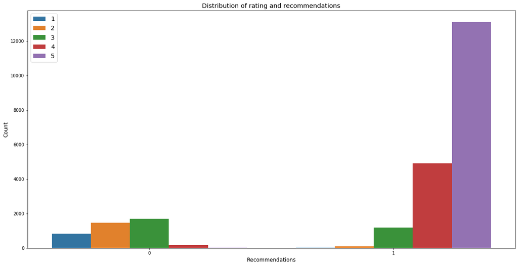

```python
#barchart showing the distribution of rating and recommendations
f, ax = plt.subplots()
f.set_size_inches(20,10)

#plt.plot(x,y,'b--',label=)


sns.countplot(x="Recommended IND", hue='Rating', data=review)

plt.xlabel("Recommendations",fontsize='large')
plt.ylabel('Count', fontsize='large')
#plt.xlim(50,80)
#plt.ylim(58,62)
plt.rcParams.update({'font.size':12})
matplotlib.rc('xtick', labelsize=20)
matplotlib.rc('ytick', labelsize=20)
plt.title('Distribution of rating and recommendations' )
ax.legend(loc='best',fontsize='large')
#plt.savefig('Distribution of rating and recommendations' +  '.png', dpi=300, bbox_inches='tight')
plt.show()
```

There are a number of reviews with missing titles. There are also few without a text review but a numerical rating with a recommendation (positive or negative). Such reviews were not considered in the analysis.

```python
#number of missing titles and reviews

miss_title = review.describe().loc['count','Rating']-review.describe().loc['count','Title']
miss_review = review.describe().loc['count','Rating']-review.describe().loc['count','Review Text']

print ('No. of missing titles:',miss_title)
print ('No. of missing reviews:',miss_review)
```

```
No. of missing titles: 3810
No. of missing reviews: 845
```

The next section analyzes the distribution of word length in the positive and negative recommendations.

```python
# subset of the dataset

recc = review[review['Recommended IND']==1]  #reviews that were recommendation
non_recc=review[review['Recommended IND']==0] #reviews that were not recommendation

surp_recc=review[((review['Recommended IND']==1) & (review['Rating']==1)) | ((review['Recommended IND']==1) & (review['Rating']==2))]
#reviews that were recommended but with poor rating

surp_non_recc=review[((review['Recommended IND']==0) & (review['Rating']==4)) | ((review['Recommended IND']==0) & (review['Rating']==5))]
#reviews that were not recommended but had high rating
```

```python
#length of words

def review_length(string):

    '''
    Measures the length of the review for each entry

    Arguments:
    string -- Input string for each review

    Returns:
    word_length -- Number of words in each review
    '''

    word_length = len(str(string).split())
    return word_length


recc.loc[:,'Length'] = recc.loc[:,'Review Text'].apply(review_length)
non_recc.loc[:,'Length'] = non_recc.loc[:,'Review Text'].apply(review_length)


print ('Average length of review in Recommended reviews:',round(recc.loc[:,'Length'].mean(),2))
print ('Average length of review in Non-Recommended reviews:',round(non_recc.loc[:,'Length'].mean(),2))
```

```
Average length of review in Recommended reviews: 57.44
Average length of review in Non-Recommended reviews: 60.96
```

The number of words in positve and negative recommneded reviews are similar. Negative recommendation reviews are slightly longer. The distribution is also quite similar. Since ratings and recommendations are closely related, this analysis was not conducted on the ratings.

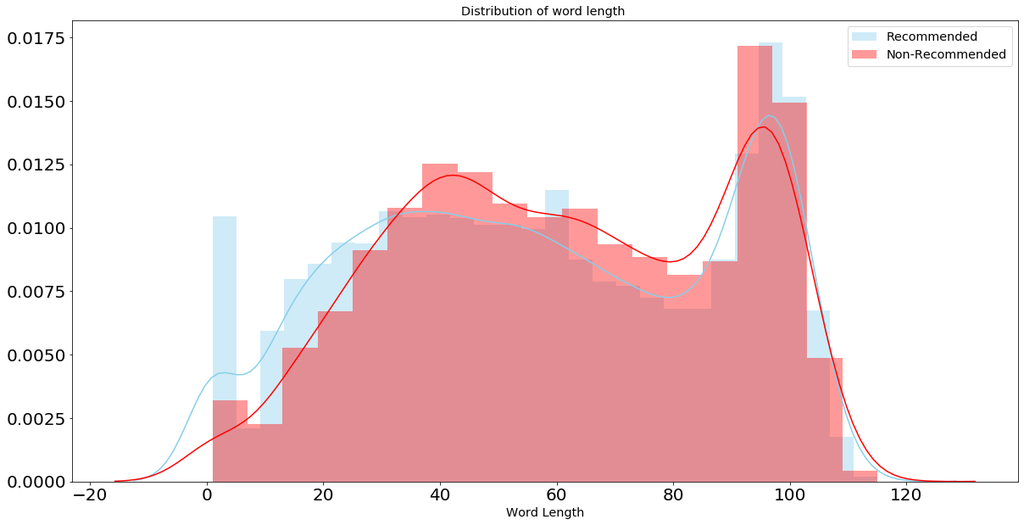

```python
# Distribution of word lengths of positve and negative recommendations

f, ax = plt.subplots()
f.set_size_inches(20,10)

#plt.plot(x,y,'b--',label=)
sns.distplot( recc["Length"] , color="skyblue", label="Recommended")
sns.distplot( non_recc["Length"] , color="red", label="Non-Recommended")

plt.xlabel("Word Length",fontsize='large')
plt.rcParams.update({'font.size':12})
matplotlib.rc('xtick', labelsize=20)
matplotlib.rc('ytick', labelsize=20)
plt.title('Distribution of word length ' )
ax.legend(loc='best',fontsize='large')
#plt.savefig('Distribution of rating and recommendations' +  '.png', dpi=300, bbox_inches='tight')
plt.show()
```

# Word Cloud

A word cloud analysis is undertaken to understand frequently used words in positive and negative recommendations.

Positive recommendation word cloud is shown below.

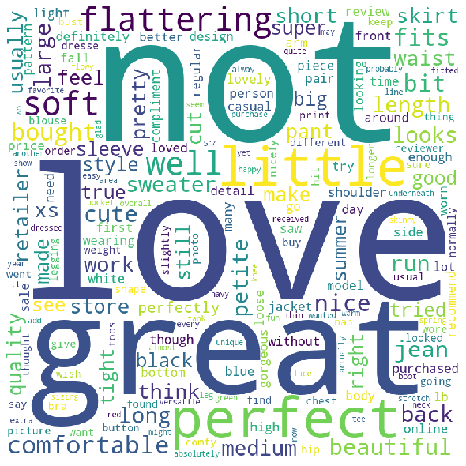

```python
#developing word cloud for Recommended reviews

pos_comment_words = ''
#adding specific words related to clothing review as stop words
custom_words=set(['dress','fit','size','color', 'will','look','wear','fabric','colors','much','ordered','-','it.','got','top','small','really','one','material','shirt','way','even'])
stopwords = set(STOPWORDS)
stopwords.remove('not') #removing a negative word which could be used in front of a positive word
stopwords=stopwords.union(custom_words)

for rev in recc['Review Text']:

    tokens = str(rev).split()

    for i in range(len(tokens)):
        tokens[i] = tokens[i].lower()

    pos_comment_words += " ".join(tokens)+" "


wordcloud = WordCloud(width = 800, height = 800,
                background_color ='white',
                stopwords = stopwords,
                collocations = False,
                min_font_size = 10).generate(pos_comment_words)

# plot the WordCloud image
plt.figure(figsize = (8, 8), facecolor = None)
plt.imshow(wordcloud)
plt.axis("off")
plt.tight_layout(pad = 0)

plt.show()
```

The word cloud for negative recommendations is shown below.

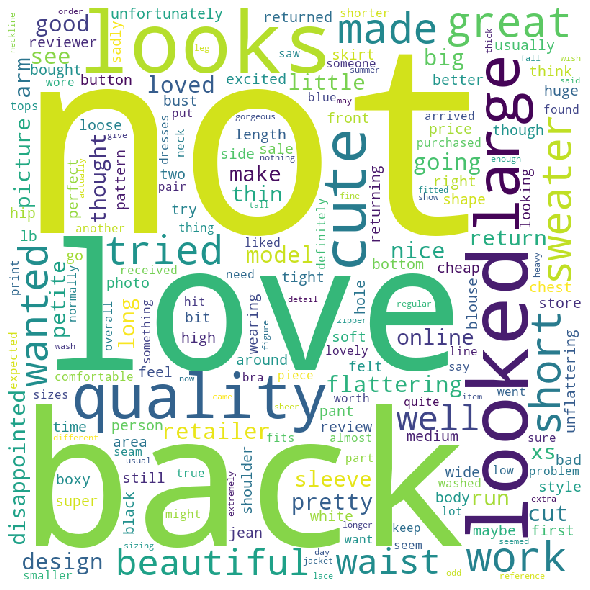

```python
#word cloud for non recommended reviews

comment_words = ''
#adding specific words related to clothing review as stop words
custom_words=set(['dress','fit','size','color', 'will','look','wear','fabric','colors','much','ordered','-','it.','got','top','small','really','one','material','shirt','way','even'])
stopwords = set(STOPWORDS)
stopwords.remove('not') #removing a negative word which could be used in front of a positive word
stopwords=stopwords.union(custom_words)

for rev in non_recc['Review Text']:

    tokens = str(rev).split()

    for i in range(len(tokens)):
        tokens[i] = tokens[i].lower()

    comment_words += " ".join(tokens)+" "


wordcloud = WordCloud(width = 800, height = 800,
                background_color ='white',
                stopwords = stopwords,
                collocations = False,
                min_font_size = 10).generate(comment_words)

# plot the WordCloud image
plt.figure(figsize = (8, 8), facecolor = None)
plt.imshow(wordcloud)
plt.axis("off")
plt.tight_layout(pad = 0)

plt.show()
```

The word clouds indicate a lot of similarity as well as some differences between the recommended and non-recommended reviews as could be expected as the review is about similar clothing items. The word NOT occurs frequently in both cases as it is used for negation. The positive reviews wordcloud shows words like love, perfect, beautiful, flattering, soft, great, cute, comfortable, pretty, fits, etc. On the other hand the negative reviews also indicate frequent usage of words like love, unfortunately, short, sadly, unflattering, pretty, cute, tight, back, return, etc.

The numerical distribution of words is analyzed next. The top 20 words that occur more in positive and negative reviews are shown below

```python
#visualizing the distribution of words

#counting number of words in negative recommendations
neg=comment_words.split()
neg_counter=collections.Counter(neg)
#counting number of words in positive recommendations
pos=pos_comment_words.split()
pos_counter=collections.Counter(pos)

#removing stopwords from the dictionaries
for word in stopwords:
    try:
        neg_counter.pop(word)
    except:
        pass
    try:
        pos_counter.pop(word)
    except:
        pass
```

```
No handles with labels found to put in legend.
```

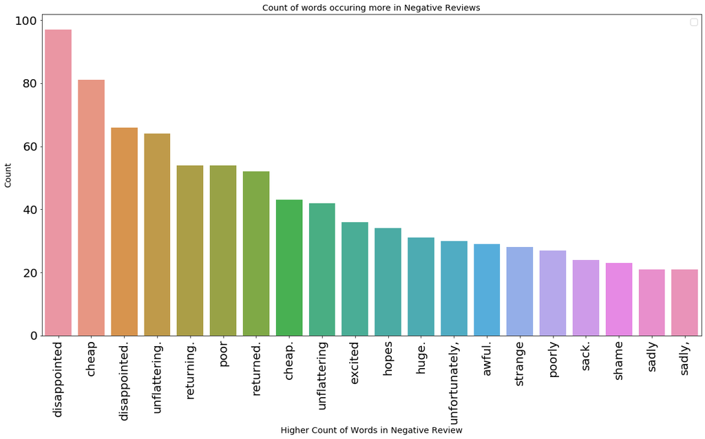

```
No handles with labels found to put in legend.
```

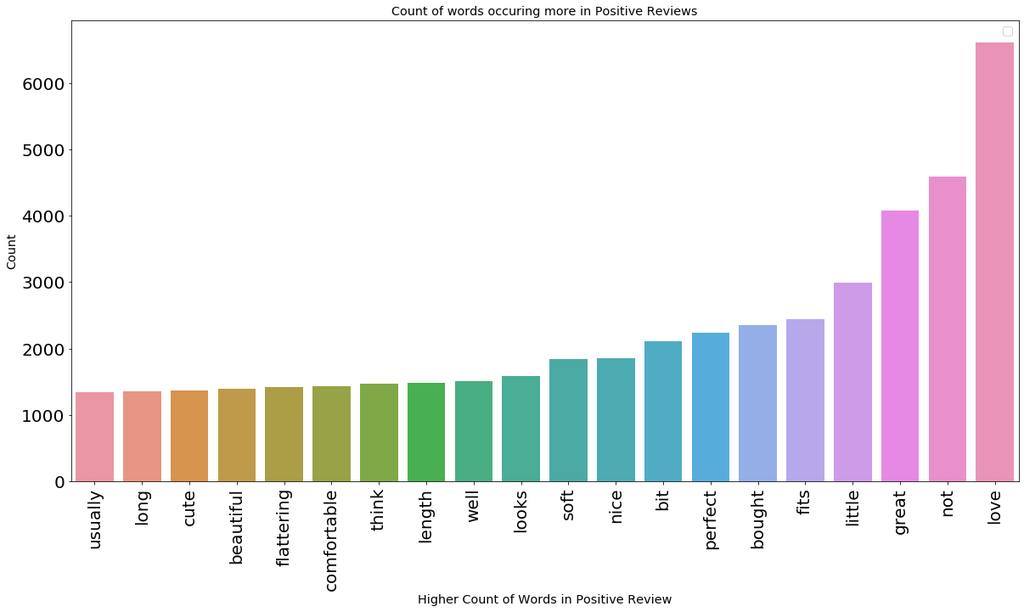

```python
#merging the positive and negative word dataframes
neg_df=pd.DataFrame(list(neg_counter.items()),columns = ['Words','Neg_Count'])
pos_df=pd.DataFrame(list(pos_counter.items()),columns = ['Words','Pos_Count'])

combined_df=pd.merge(pos_df,neg_df,on='Words',how='outer')
combined_df = combined_df.fillna(0)
combined_df['Difference']=combined_df['Pos_Count']-combined_df['Neg_Count']

combined_df = combined_df.sort_values(by=['Difference'], ascending=True)
strong_neg =combined_df.head(20)

strong_neg['Difference']=abs(strong_neg['Difference'])
strong_pos=combined_df.tail(20)

#barchart showing the distribution of more frequently observed words in negative reviews
f, ax = plt.subplots()
f.set_size_inches(20,10)

#plt.plot(x,y,'b--',label=)

sns.barplot(x="Words", y='Difference', data=strong_neg)

plt.xlabel("Higher Count of Words in Negative Review",fontsize='large')
plt.ylabel('Count', fontsize='large')
plt.xticks(rotation=90)
plt.rcParams.update({'font.size':12})
matplotlib.rc('xtick', labelsize=20)
matplotlib.rc('ytick', labelsize=20)
plt.title('Count of words occuring more in Negative Reviews' )
ax.legend(loc='best',fontsize='large')
#plt.savefig('Distribution of rating and recommendations' +  '.png', dpi=300, bbox_inches='tight')
plt.show()



#barchart showing the distribution of more frequently observed words in positive reviews
f, ax = plt.subplots()
f.set_size_inches(20,10)

#plt.plot(x,y,'b--',label=)

sns.barplot(x="Words", y='Difference', data=strong_pos)

plt.xlabel("Higher Count of Words in Positive Review",fontsize='large')
plt.ylabel('Count', fontsize='large')
plt.xticks(rotation=90)
plt.rcParams.update({'font.size':12})
matplotlib.rc('xtick', labelsize=20)
matplotlib.rc('ytick', labelsize=20)
plt.title('Count of words occuring more in Positive Reviews' )
ax.legend(loc='best',fontsize='large')
#plt.savefig('Distribution of rating and recommendations' +  '.png', dpi=300, bbox_inches='tight')
plt.show()
```

Analysis of the words indicate that the negative reviews show a higher count of the following words:dissapointed, cheap, unflattering, returning, poor, unfortunately, awful, strange, poorly, shame, sadly. These words generally have a negative connotation. Similarly, the positive reviews exhibited higher count of the following words: well, looks, soft, nice, perfect, fits, great, love, etc. Although the positive review also included several words which were neutral.

# Bidirectional LSTM for Recommendation Prediction

Sentiment analysis was carried out using Bidirectional LSTM on the recommendation. Several architecture of the neural network was considered including Unidirectional LSTM and two layers LSTM. The performance difference was minimal.

The first step involved cleaning the text and identifying the maximum sequence length after tokenizing to enable padding. This padded vector will be used as input.

```python
#Word Preprocessing
#creating subset of the dataframe

recc_lstm=review[['Review Text','Rating','Recommended IND']]
recc_lstm=recc_lstm.dropna()  #dropping missing text cases in reviews

#converting the panda series to numpy array
X=recc_lstm['Review Text']
X=np.array(X)
Y=recc_lstm['Recommended IND']
Y=np.array(Y)

#tokenizing the strings
tokenizer=Tokenizer()
tokenizer.fit_on_texts(X)
sequencer=tokenizer.texts_to_sequences(X)

#finding maximum length of a review

maxLen=0
for string in sequencer:
    temp=len(string)
    if temp>maxLen:
        maxLen=temp

print ('Maximum sequence length:',maxLen)
```

```
Maximum sequence length: 116
```

## GloVe Embeddings

Pre-trained GloVe embeddings were used to create the embedding matrix. The embedding vectors are 50 dimensional and the vocabulary is about 400k words. The word_to_index and index_to_word dictionary was created from the review text

```python
#creating the word to index and index to word vectors
word_to_index=tokenizer.word_index #dictionary that maps words in the reviews to indices
index_to_word=tokenizer.index_word #dictionary that maps indices back to words

#loading the GloVe embeddings
embeddings_dict = {} #dictionary of words and their correspondng GloVe vector representation
indices=0

with open("glove.6B.50d.txt", 'r', encoding ='utf8') as f:
    for line in f:
        words = line.split()
        word = words[0]
        vector = np.asarray(words[1:], "float32")
        embeddings_dict[word] = vector
        indices+=1
```

```python
#preparing embedding matrix
vocab_size=len(word_to_index)+1 #to account for out of vocabulary words
embedding_dim=50 #number of dimensions chosen in the GloVe representation
present=0
absent=0
embedding_matrix = np.zeros((vocab_size, embedding_dim))
for word, i in word_to_index.items():
    #embedding_vector = embeddings_dict[word]
    embedding_vector=  embeddings_dict.get(word)
    if embedding_vector is not None:
        embedding_matrix[i] = embedding_vector
        present+=1
    else:
        absent+=1

print ("No. of words in the matrix",present)
print ("No.of missing words",absent)
```

```
No. of words in the matrix 12064
No.of missing words 2783
```

Quite a number of words in the reviews are missing in the GloVe representation. A review of the missing words indicate multiple words with wrong spelling, numerical numbers related to weight or height, and few words like didn't (did not), couldn't, etc. The GloVe representation does not handle such words well. The performance of the model did not improve significantly when we trained the embedding layer. In the interest of saving time, we will use the GloVe embeddings instead of training our own embedding matrix.

The review text is next padded to have equal length as the max length. The sequences are then divided into training and test data set.

```python
#preprocessing the text to create indices

def sentences_to_indices(sequencer,maxLen):

    '''
    Converts the tokenized sequencer to 2D matrix for each text entry.
    Each row in the matrix is one review. Each column indice indicate one word in the text.

    Arguments:
    sequencer -- List of list comprisong of text reviews converted to indices.
    maxLen -- Maximum length of the nested list consisting of text converted to indices in the sequencer list

    Returns:
    X_indices -- 2D matrix where each row corresponds to each review. Each column indice correspond to a word in the review.
    '''

    X_indices=np.zeros((len(sequencer),maxLen))
    for i in range(len(sequencer)):
        j=0
        for n in sequencer[i]:
             X_indices[i,j]= n
             j+=1
    return X_indices

X_indices=sentences_to_indices(sequencer,maxLen)
```

```python
#dividing into training and test data set
np.random.seed(2)
X_tr,X_test,Y_tr,Y_test=train_test_split(X_indices,Y,test_size=0.1)
```

## Building the Model

A bidirectional LSTM model was built with 10 units in each layer. The second layer is many-to-one architecture. The LSTM output was fed into a dense layer of 10 units and then Sigmoid activation was used on the next dense layer to predict the recommendation. Recommendation is a binary classification problem. Therefore, the loss function was binary_crossentropy and the Adam optimizer was used.

```python
#building the Bidirectional LSTM model
early_stopping=EarlyStopping(monitor='val_loss',patience=20)
model_save=ModelCheckpoint('top_model.hdf5',save_best_only=True)
model=Sequential()
model.add(Embedding(
    input_dim=vocab_size,
    output_dim=embedding_dim,
    input_length=maxLen,
    embeddings_initializer=Constant(embedding_matrix),
    trainable=False,
))
model.add(Bidirectional(LSTM(units = 10, return_sequences= True)))
#model.add(Dropout(rate=0.5))
model.add(Bidirectional(LSTM(units = 10, return_sequences= False)))
model.add(Dense(10,activation='relu'))
model.add(Dense(1,activation='sigmoid'))

model.summary()
```

```
Model: "sequential_1"
_________________________________________________________________
Layer (type)                 Output Shape              Param #
=================================================================
embedding_1 (Embedding)      (None, 116, 50)           742400
_________________________________________________________________
bidirectional_1 (Bidirection (None, 116, 20)           4880
_________________________________________________________________
bidirectional_2 (Bidirection (None, 20)                2480
_________________________________________________________________
dense_1 (Dense)              (None, 10)                210
_________________________________________________________________
dense_2 (Dense)              (None, 1)                 11
=================================================================
Total params: 749,981
Trainable params: 7,581
Non-trainable params: 742,400
_________________________________________________________________
```

```
WARNING:tensorflow:From C:\Users\basus_000\anaconda3\lib\site-packages\tensorflow\python\ops\nn_impl.py:180: add_dispatch_support.<locals>.wrapper (from tensorflow.python.ops.array_ops) is deprecated and will be removed in a future version.
Instructions for updating:
Use tf.where in 2.0, which has the same broadcast rule as np.where
WARNING:tensorflow:From C:\Users\basus_000\anaconda3\lib\site-packages\keras\backend\tensorflow_backend.py:422: The name tf.global_variables is deprecated. Please use tf.compat.v1.global_variables instead.

Train on 18338 samples, validate on 2038 samples
```

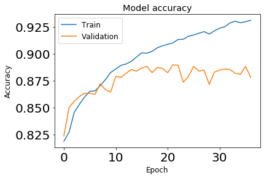

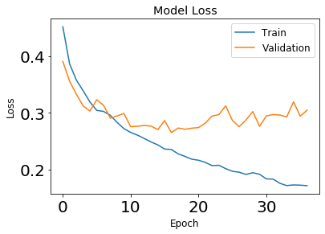

```python
#compiling and fitting the model

model.compile(optimizer='adam',loss='binary_crossentropy',metrics=['accuracy'])
model_his=model.fit(X_tr, Y_tr, epochs = 400, batch_size = 32, validation_split=0.1, shuffle=True,verbose=True,callbacks=[early_stopping,model_save])


plt.figure()
plt.plot(model_his.history['accuracy'])
plt.plot(model_his.history['val_accuracy'])
plt.title('Model accuracy')
plt.ylabel('Accuracy')
plt.xlabel('Epoch')
plt.legend(['Train','Validation'])
plt.show()

plt.figure()
plt.plot(model_his.history['loss'])
plt.plot(model_his.history['val_loss'])
plt.title('Model Loss')
plt.ylabel('Loss')
plt.xlabel('Epoch')
plt.legend(['Train','Validation'])
plt.show()
```

# Model Evaluation

The model was fitted on training data with training accuracy of 93% and validation accuracy of 88%. The training was stopped to avoid overfitting as the validation loss was increasing. The model when tested on test data showed an accuracy of 87%. The majority class accuracy is 81%. This indicates that the model improved the performance by approximately 7%. Other metrics will be analyzed next. The class prediction is done with a threshold of 0.5.

```python
#evaluating the model on the test data set

print ('Loss=',model.evaluate(X_test,Y_test)[0])
print ('Accuracy=',model.evaluate(X_test,Y_test)[1])
```

```
Loss= 0.32245223502449644
Accuracy= 0.8728476762771606
```

```python
# Predicting the class
pred=model.predict_proba(X_test)
pred_class=np.array([0 if i<0.5 else 1 for i in pred]) #using threshold of 0.5
pred_class=pred_class.reshape(pred_class.shape[0],1)
Y_test=Y_test.reshape((Y_test.shape[0],1))
diff_new=Y_test-pred_class
```

```
Bidirectional LSTM
              precision    recall  f1-score   support

           0       0.67      0.66      0.66       428
           1       0.92      0.92      0.92      1837

    accuracy                           0.87      2265
   macro avg       0.79      0.79      0.79      2265
weighted avg       0.87      0.87      0.87      2265
```

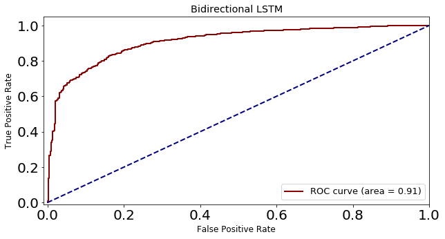

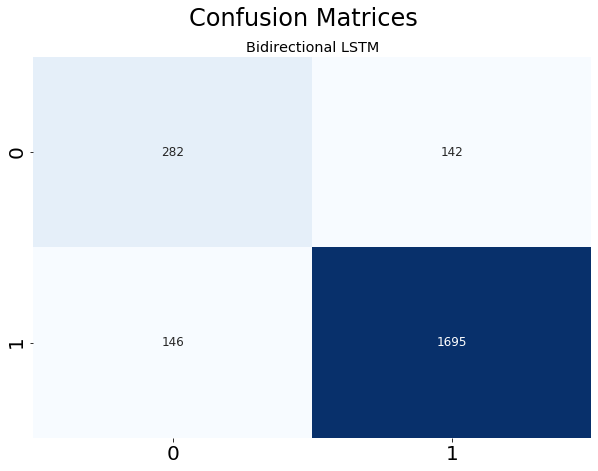

```python
# ROC curve
Y_test=Y_test.reshape((Y_test.shape[0],1))
fpr_lstm,tpr_lstm,_ = roc_curve(Y_test,pred)
roc_auc_lstm = auc(fpr_lstm,tpr_lstm)

f, ax = plt.subplots()
f.set_size_inches(10,5)
plt.plot(fpr_lstm, tpr_lstm, color='darkred', lw=2, label='ROC curve (area = {:0.2f})'.format(roc_auc_lstm))
plt.plot([0, 1], [0, 1], color='navy', lw=2, linestyle='--')
ax.set(xlim=[-0.01, 1.0], ylim=[-0.01, 1.05])
ax.set(xlabel ='False Positive Rate', ylabel = 'True Positive Rate', title = 'Bidirectional LSTM')
plt.legend(loc='lower right', fontsize=13)

#Confusion Matrix

lstm_cm=np.around(confusion_matrix(pred_class,Y_test),0)


plt.figure(figsize=(10,7))
plt.suptitle("Confusion Matrices",fontsize=24)

plt.title("Bidirectional LSTM")
sns.heatmap(lstm_cm, annot = True,fmt='0g',cmap="Blues",cbar=False)

#Classification Metrics


print("Bidirectional LSTM")
print(mt.classification_report(Y_test, pred_class))
```

# Analysis of Wrong Predictions

```python
#calculating false positive and negative count
print ('False Negative Count:',count_nonzero(diff_new==1))
print ('False Positive Count:',count_nonzero(diff_new==-1))
print ('Correct Prediction Count:',count_nonzero(diff_new==0))
print ('\n')

#Identifying wrong predictions and storing the index in two lists

false_pos_index=[]
false_neg_index=[]

for i in range(len(diff_new)):
    if diff_new[i][0]>0:
        false_neg_index.append(i)
    if diff_new[i][0]<0:
        false_pos_index.append(i)

#Randomly shuffling the index of positive and negative reviews
np.random.seed(7)
np.random.shuffle(false_pos_index)
np.random.shuffle(false_neg_index)
```

```
False Negative Count: 142
False Positive Count: 146
Correct Prediction Count: 1977
```

### Ten Randomly Selected False Positive Predictions

```python
#The index were shuffled in the previous cell. We choose the first 10 reviews.
print ('\n')
for i in range(10):
     index=false_pos_index[i]
     print ('\n')
     wrong_pred_text=[]  #stores the wrong predicted review text
     for w in X_test[index]:
            if w==0.0:
                 pass
            else:
                 wrong_pred_text.append(index_to_word[w])  #converting index to word
     print (str(index) + ':')
     print (' '.join(wrong_pred_text))  #joining the word
```

```
255:
i have always bought interesting pretty wearable dresses for my daughters at retailer now the dresses are just retro funky sad to see


1932:
i have mixed feelings about this dress the color is fantastic not too bright not too dark the material is super soft and comfortable and the length was perfect i did end up returning this item though as no matter which bra i chose the straps showed it just was not hitting my right on the shoulders i…


743:
i got this dress in the mail today and really thought i was going to love it the color is a beautiful rich red which was a nice surprise i was expecting more of a dusty red from the picture love the fabric soft and appears to be good quality the length is perfect hit right at my knees size small the…


658:
i bought this suit based on the great reviews i was so bummed when i tried it on the top fit so well but the bottom kept bunching up my torso is on the longer side so maybe that's why the bottoms keep coming up every time i pulled the shorts down the top would come down too and vice versa i am 5'5 a…


1475:
i ordered this dress expecting a cool lightweight summer dress i believe it says cotton in the description however the material is a very heavy cotton linen blend would have much preferred a better quality fabric the color is a nice green and is well made it runs large except in the bust which fit w…


1622:
this dress looked gorgeous in the monthly catalog ordered in hopes to wear in easter i felt it was frumpy and just ok color was pretty but overall i didn't love it like i hoped to


2017:
doesn't feel like cotton jersey feels like a thin version of the seamless cami it's not soft as i expected it's much thinner than expected too


1793:
this was just not flattering for me looked too much like a maternity dress i can't really do a belted waist so perhaps that would make this dress more versatile for someone else i was sorry to have to return because it goes well with sandals and boots


1148:
my usual size was a bit large and baggy in most areas but the bust was sooo soo small the button popped and i had barely moved do not recommend this one for anyone with a bust the detailing is very pretty though for someone that can make this work


1182:
it's a beautiful lace designed tank top in a vibrant navy blue however the lace on the hemlines were snagged the top was much shorter than i had anticipated i'm returning it to the store unfortunately
```

### Ten Randomly Selected False Negative Recommendations

```python
#The index were shuffled in the previous cell. We choose the first 10 reviews.
print ('\n')
for i in range(10):
     index=false_neg_index[i]
     print ('\n')
     wrong_pred_text=[]  #stores the wrong predicted review text
     for w in X_test[index]:
            if w==0.0:
                 pass
            else:
                 wrong_pred_text.append(index_to_word[w])  #converting index to word
     print (str(index) + ':')
     print (' '.join(wrong_pred_text))  #joining the word
```

```
306:
this gorgeous amp amp amp beautiful dress is hampered by a see through unlined bodice and all viscose polyester fabrication by the way did you see the price tag at least the skirt is lined if you have deep pockets and don't mind the slightly rough fabric go for it and wear a nice bra size up if you'…


1015:
this midi skirt arrived and i tried it on immediately the fit was perfect and i wanted it badly enough to say that it would balance my 5'5 height and 135 lbs if i just wore a higher heel shoe then i saw the grey lining showing from the back of the skirt through the scalloped front it's a beautiful s…


545:
1 i'm 5'6 tall with a short waist and long legs and this skirt came all the way down to my ankles i would have kept it if it had stopped mid calf like in the photo 2 i'm 38 32 40 and the size 12 fit me perfectly in the waist hip area so i would say it runs true to size 3 the buttons lay nice and fla…


748:
this is a very pretty color loved the flow and the length of this top however the neck hole seemed too small for the top all the embroidering is at the neck and makes that part very stiff going back


2237:
i bought this jumpsuit in both fabrics i adored the fit and feel of both but sadly the graphic fabric was not handled well in the construction three examples a thin white piece along one leg seam made it look like a hole mismatched large pieces of white in the crotch area looked sloppy and wrong wor…


1693:
i saw this dress and loved everything about it i was so sad when i tried it on and it was just too big they were out of the smaller size so i had to return it the dress is well made and the color is just a bit neon compared to the picture


973:
the shirt was better than it actually looked online the only downfall was that there was a pulled thread on the shirt when i received it it's something i can probably fix just a little disappointed receiving in that shape i would recommend this top very flattering and dressy if you want it to be


932:
i opened the package and loved this skirt immediately i held it up and the waist is tiny i'm usually a size 6 but sometimes go for a size 8 at retailer i'm 5'6 and 126 lbs i would have needed at least 4 extra inches in the waist band to close the zipper i wonder if this is a british size 8 or someth…


1108:
i was surprised how soft and comfy the fabric is on this top when i tried it on i didn't want to take it off it's a little bigger than i would like i got a small and am usually between xs and s may have sized down if the top were available but the fit and cut are flattering


1212:
i was so excited to get these i paid for two day shipping and ordered medium and large sadly they did not fit i usually wear medium but ordered both just in case i'm very disappointed that they run so small and are not true to size they are super cute from someone skinny
```

## Notes:

Recommendation is a binary choice - positive or negative. Often in clothing review, the reviewer might like a dress but returned it due to size or fit issues. On the other hand, there are many reviews where the reviewer appreciates certain features like color or fabric but dislikes the cut or some design. This kind of review points to a neutral outlook and it was difficult to determine if the recommendation is positive or negative. Such reviews typically consisted of both positive words and negative words. The analysis will be repeated with Ratings to checks if it performs better.

# Bidirectional LSTM for Rating Prediction

The ratings are in a scale of 1 to 5. For the purpose of this sentiment classification, a New Rating variable is created with ratings 4 and 5 classified as 1 (Positive)and rating 1 and 2 are classified as 0 (Negative). Rating 3 is excluded from the model. A two layer Bidirectional LSTM model with only ten nodes in each layer is created to reduce overfitting. Increasing the number of nodes did not improve the accuracy of the validation set.

As the sample size changed, the word to index dictionary and the embedding matrix has to be calculated again.

```python
#preprocessing the review text and one-hot encoding of Ratings

def reclassifying (var):

    '''
    Reclassifies the ratings to two categories: 1 (Positive and >3) and 0 (Negative and <3)

    Arguments:
    var -- Acts as dummy input for the original rating

    Returns:
    New Rating
    '''

    if var>3:
        return 1
    if var<3:
        return 0

new_recc_lstm=recc_lstm[recc_lstm['Rating']!=3]
new_recc_lstm['New Rating']=new_recc_lstm['Rating'].apply(reclassifying)

new_recc_lstm['New Rating'] = new_recc_lstm['New Rating'].astype('category')
#recc_lstm['New Rating']=recc_lstm['New Rating'].cat.codes
#Y_rating = to_categorical(recc_lstm['New Rating'])
Y_rating=np.array(new_recc_lstm['New Rating'])

#converting the panda series to numpy array. Recalculating X as rating 3 were excluded.
X_rating=new_recc_lstm['Review Text']
X_rating=np.array(X_rating)

#tokenizing the strings
rat_tokenizer=Tokenizer()
rat_tokenizer.fit_on_texts(X_rating)
sequencer_rating=rat_tokenizer.texts_to_sequences(X_rating)

X_rating_indices=sentences_to_indices(sequencer_rating,maxLen)

r_maxLen=0
for string in sequencer_rating:
    temp=len(string)
    if temp>r_maxLen:
        r_maxLen=temp

print ('Maximum sequence length:',r_maxLen)

X_rating_indices=sentences_to_indices(sequencer_rating,r_maxLen)

#dividing into training and test data set
np.random.seed(199)
X_rating_train,X_rating_test,Y_rating_train,Y_rating_test=train_test_split(X_rating_indices,Y_rating,test_size=0.1)
```

```
Maximum sequence length: 115
```

```python
#recreating the word to index vector and the embedding matrix

rat_word_to_index=rat_tokenizer.word_index #dictionary that maps words in the reviews to indices
rat_index_to_word=rat_tokenizer.index_word #dictionary that maps indices back to words

#preparing embedding matrix
rat_vocab_size=len(rat_word_to_index)+1 #to account for out of vocabulary words
rat_embedding_dim=50 #number of dimensions chosen in the GloVe representation
present=0
absent=0
rat_embedding_matrix = np.zeros((rat_vocab_size, rat_embedding_dim))
for word, i in rat_word_to_index.items():
    rat_embedding_vector=  embeddings_dict.get(word)
    if rat_embedding_vector is not None:
        rat_embedding_matrix[i] = rat_embedding_vector
        present+=1
    else:
        absent+=1

print ("No. of words in the matrix",present)
print ("No.of missing words in the matrix",absent)
```

```
No. of words in the matrix 11453
No.of missing words in the matrix 2520
```

```python
#building the Bidirectional LSTM model
rat_early_stopping=EarlyStopping(monitor='val_loss',patience=10)
rat_model_save=ModelCheckpoint('rating_model.hdf5',save_best_only=True)
rat_model=Sequential()
rat_model.add(Embedding(
    input_dim=rat_vocab_size,
    output_dim=rat_embedding_dim,
    input_length=r_maxLen,
    #embeddings_initializer=Constant(rat_embedding_matrix),
    weights=[rat_embedding_matrix],
    trainable=False,
))
rat_model.add(Bidirectional(LSTM(units = 10, return_sequences= True)))
#rat_model.add(Dropout(rate=0.5))
rat_model.add(Bidirectional(LSTM(units = 10, return_sequences= False)))
#rat_model.add(Dropout(rate=0.5))
rat_model.add(Dense(10,activation='relu'))
rat_model.add(Dense(5,activation='relu'))
rat_model.add(Dense(1,activation='sigmoid'))

rat_model.summary()
```

```
Model: "sequential_2"
_________________________________________________________________
Layer (type)                 Output Shape              Param #
=================================================================
embedding_2 (Embedding)      (None, 115, 50)           698700
_________________________________________________________________
bidirectional_3 (Bidirection (None, 115, 20)           4880
_________________________________________________________________
bidirectional_4 (Bidirection (None, 20)                2480
_________________________________________________________________
dense_3 (Dense)              (None, 10)                210
_________________________________________________________________
dense_4 (Dense)              (None, 5)                 55
_________________________________________________________________
dense_5 (Dense)              (None, 1)                 6
=================================================================
Total params: 706,331
Trainable params: 7,631
Non-trainable params: 698,700
_________________________________________________________________
```

```
Train on 17300 samples, validate on 536 samples
```

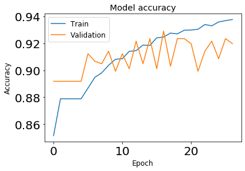

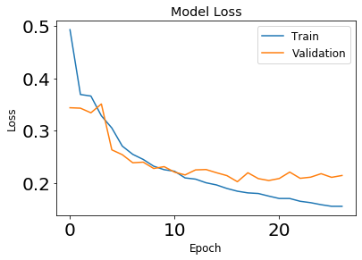

```python
#compiling and saving the model
rat_model.compile(optimizer='adam',loss='binary_crossentropy',metrics=['accuracy'])
rat_model_his=rat_model.fit(X_rating_train,Y_rating_train, epochs = 1000, batch_size = 128, validation_split=0.03, shuffle=True,verbose=True,callbacks=[rat_early_stopping,rat_model_save])


plt.figure()
plt.plot(rat_model_his.history['accuracy'])
plt.plot(rat_model_his.history['val_accuracy'])
plt.title('Model accuracy')
plt.ylabel('Accuracy')
plt.xlabel('Epoch')
plt.legend(['Train','Validation'])
plt.show()

plt.figure()
plt.plot(rat_model_his.history['loss'])
plt.plot(rat_model_his.history['val_loss'])
plt.title('Model Loss')
plt.ylabel('Loss')
plt.xlabel('Epoch')
plt.legend(['Train','Validation'])
plt.show()
```

# Model Evaluation

```python
#evaluating the model on the test data set

print ('Loss=',rat_model.evaluate(X_rating_test,Y_rating_test)[0])
print ('Accuracy=',rat_model.evaluate(X_rating_test,Y_rating_test)[1])
```

```
Loss= 0.18161216751116918
Accuracy= 0.9334006309509277
```

```python
# Predicting the class
rat_pred=rat_model.predict_proba(X_rating_test)
rat_pred_class=np.array([0 if i<0.5 else 1 for i in rat_pred]) #using threshold of 0.5
rat_pred_class=rat_pred_class.reshape(rat_pred_class.shape[0],1)
Y_rating_test=Y_rating_test.reshape((Y_rating_test.shape[0],1))
diff_new_rating=Y_rating_test-rat_pred_class
```

```
Bidirectional LSTM for Rating
              precision    recall  f1-score   support

         0.0       0.71      0.66      0.68       215
         1.0       0.96      0.97      0.96      1767

    accuracy                           0.93      1982
   macro avg       0.83      0.81      0.82      1982
weighted avg       0.93      0.93      0.93      1982
```

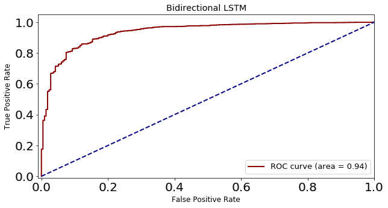

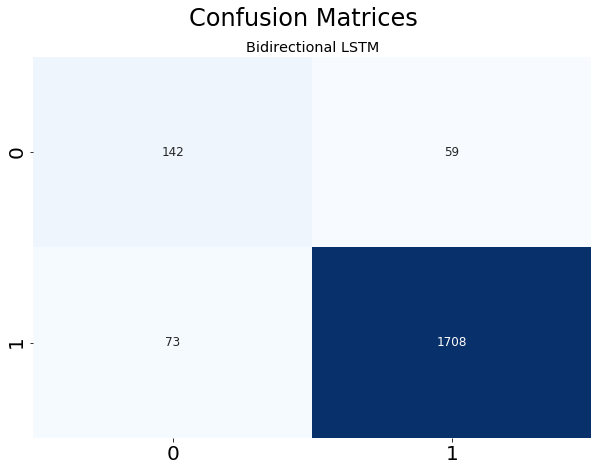

```python
# ROC curve
fpr_rating_lstm,tpr_rating_lstm,_ = roc_curve(Y_rating_test,rat_pred)
roc_auc_lstm_rating = auc(fpr_rating_lstm,tpr_rating_lstm)

f, ax = plt.subplots()
f.set_size_inches(10,5)
plt.plot(fpr_rating_lstm, tpr_rating_lstm, color='darkred', lw=2, label='ROC curve (area = {:0.2f})'.format(roc_auc_lstm_rating))
plt.plot([0, 1], [0, 1], color='navy', lw=2, linestyle='--')
ax.set(xlim=[-0.01, 1.0], ylim=[-0.01, 1.05])
ax.set(xlabel ='False Positive Rate', ylabel = 'True Positive Rate', title = 'Bidirectional LSTM')
plt.legend(loc='lower right', fontsize=13)

#Confusion Matrix

rating_lstm_cm=np.around(confusion_matrix(rat_pred_class,Y_rating_test),0)


plt.figure(figsize=(10,7))
plt.suptitle("Confusion Matrices",fontsize=24)

plt.title("Bidirectional LSTM")
sns.heatmap(rating_lstm_cm, annot = True,fmt='0g',cmap="Blues",cbar=False)

#Classification Metrics


print("Bidirectional LSTM for Rating")
print(mt.classification_report(Y_rating_test, rat_pred_class))
```

The model performs quite well with about 93% accuracy. The recall and precision for positive reviews is very high. The majority class prediction would have resulted in an accuracy of 89%. The recall and precision for the negative reviews was low (0.66-0.7). If identifying negative reviews is more important, it might be useful to increase the threshold.

# Analysis of Wrong Predictions

```python
#calculating false positive and negative count
print ('False Negative Count:',count_nonzero(diff_new_rating==1))
print ('False Positive Count:',count_nonzero(diff_new_rating==-1))
print ('Correct Prediction Count:',count_nonzero(diff_new_rating==0))
print ('\n')

#Identifying wrong predictions and storing the index in two lists

rating_false_pos_index=[]
rating_false_neg_index=[]

for i in range(len(diff_new_rating)):
    if diff_new_rating[i][0]>0:
        rating_false_neg_index.append(i)
    if diff_new_rating[i][0]<0:
        rating_false_pos_index.append(i)

#Randomly shuffling the index of positive and negative reviews
np.random.seed(8)
np.random.shuffle(rating_false_pos_index)
np.random.shuffle(rating_false_neg_index)
```

[output not shown]

## False Positive Cases

```python
#The index were shuffled in the previous cell. We choose the first 10 reviews.
print ('\n')
for i in range(10):
     rating_index=rating_false_pos_index[i]
     print ('\n')
     rating_wrong_pred_text=[]  #stores the wrong predicted review text
     for w in X_rating_test[rating_index]:
            if w==0.0:
                 pass
            else:
                 rating_wrong_pred_text.append(rat_index_to_word[w])  #converting index to word
     print (str(rating_index) + ':')
     print (' '.join(rating_wrong_pred_text))  #joining the word
```

```
1674:
i purchased this shirt in white and black the white is more ivory isn and is a bit thin see through the shirts can be worn with jeans or dressed up with a skirt i just wish it was a little more form fitting i do like the hint of stretch in the fabric very comfortable as well


1977:
it is a beautiful sweater but it is cropped and boxy


1409:
 i would


1568:
these pants are the perfect color and i love the detail of the zippered pockets i was so excited when they came in the mail and fit pretty well they were slightly loose but i thought they would hold their shape and the size smaller would be too small after an hour of wear i was swimming in these i c…


809:
i ordered these in m 5'8 140 lbs and they are tts they fit well and are neither tight nor loose the issue that i have with them and the reason that i sent them back is that the material although comfortable is completely transparent if i were to try to run out to get the mail in these the whole neig…


1008:
i couldn't wait to get this top in the mail since they didn't have it at my local retailer but i was so disappointed in both the quality and fit the white is completely see thru i can't believe how sheer the material is especially for the price even as the shirt is lying down i can see through both …


1002:
this dress was too cute to pass up i loved it online but when i got it home it was so tight i couldn't zip up my normal size the length was perfect on me being 5'7 the fabric and detail was beautiful if you have a bust order a size up beautiful dress just really snug up top


13:
there isn't a whole lot that i did like about this dress the shoulders have large poufs the fabric isn't very soft and it's not flattering maybe with a belt i could be tempted but i wasn't too fond of the dress


1392:
after reading all the reviews and sizing down one size i got my top size m i usually wear m l depending on the style i'm 6 ft tall 160 lb i like my clothing loose but not as loose as this top i should have gone to xxxxxs if such exists no wonder there is such a low leap in price it is a good quality…


1976:
i really liked the look of the orange so ordered an xs i prefer a s petite but it is sold out the xs arrives and while i still like the color the fit is really weird the cowl is very high up but the sleeves are still long it looks nothing like the photo i cannot see how the cowl sits on the model's …
```

## False Negative Cases

```python
#The index were shuffled in the previous cell. We choose the first 10 reviews.
print ('\n')
for i in range(10):
     rating_index=rating_false_neg_index[i]
     print ('\n')
     rating_wrong_pred_text=[]  #stores the wrong predicted review text
     for w in X_rating_test[rating_index]:
            if w==0.0:
                 pass
            else:
                 rating_wrong_pred_text.append(rat_index_to_word[w])  #converting index to word
     print (str(rating_index) + ':')
     print (' '.join(rating_wrong_pred_text))  #joining the word
```

```
1916:
the high low hem is interesting and the fit looks great i did find that i needed one size larger than normal maybe that's bc these are high rise there is also absolutely no stretch in the fabric


1576:
ordered this is the navy in a size m i'm 5' 5 135 lbs 34d it was huge it is also very billowy but i'm going to try it in a petite s i also changed colors to the ivory as the navy was really plain hoping this size change works


1785:
really liked the color but the style was too cropped and boxy for me this sweater was short wide and unflattering however i like this designer so i ordered another style with a different silhouette


1018:
i bought this dress online last week in large part based on all the positive reviews then i saw it in the store i didn't try it on because it was already on the way to me and i had ordered a petite anyway and the store didn't carry petites i have to say when i saw it hanging in the store i was disap…


222:
this was such a cute suit but strange how they designed it top runs super low and it almost did not cover my breast area runs small i had to return because fit was way to small for a large suit


286:
i agree with the other reviewers about the versatility and the fit of the dress i am 5'9 and yes the pockets hit just a tad high but the fit of the bodice and bust is so great that i am willing to overlook this small flaw the only thing that has really bothered me about the dress that i haven't seen…


1853:
i bought the m l 5'4 130lb and love the way it hangs and the length and the fact that it can be worn over a lightweight top the color and feel of the fabric are very nice


1464:
i always wear a small in retailer tops and this was very tight in the chest had to return for a medium cute top otherwise


1391:
confused and a little disappointed because the s is too tight in my shoulders and the m is too big all around weird because i'm a 39 chest breasts so m shouldn't look that baggy on me please sanctuary make a petite version maybe that will solve my issue otherwise this jacket is soft and relaxed and …


1614:
this dress brought out my tamed inner kitty there's a collar so of course it's tamed i'm in love with this unique print that roars retailer to all who admire this is not a hot weather dress because of long sleeves and fabric dropped stars cuz it's yucky poly rayon and you need to size down or you'll…
```

## Conclusions

The GloVe embeddings were based on the Wikipedia dataset. Since, reviews are written in a more casual form, it might be useful to rerun the model with the Twitter dataset GloVe embeddings.